# Missing data – Impact of some common solutions

Author

Affiliation

Aurélie Bertrand, Laura Symul

Université catholique de Louvain

Published

November 27, 2026

# Full data

## Descriptive statistics

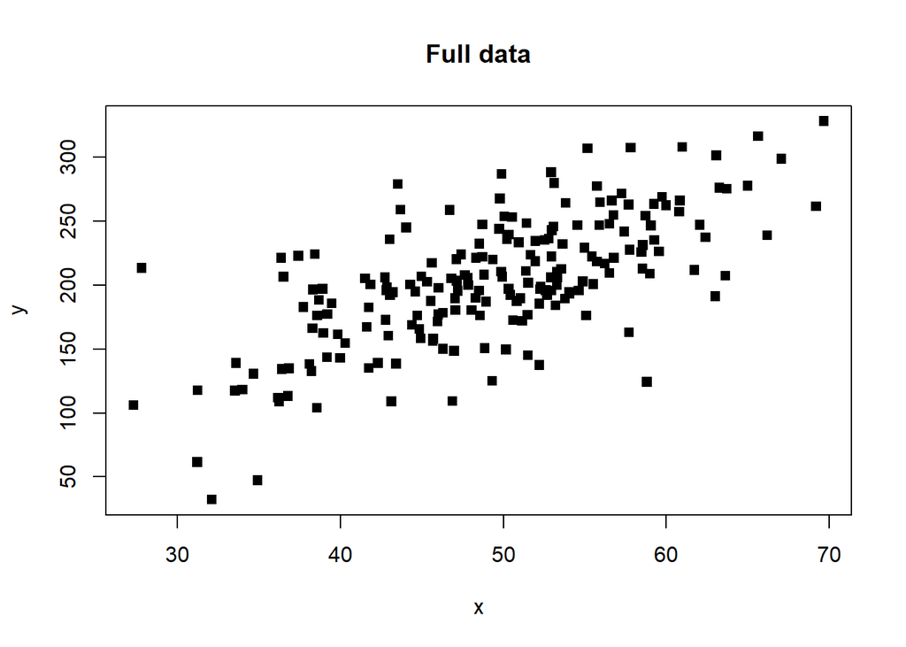

| Statistic | Full_data |
| --- | --- |
| Sample mean of $X$, $\overline{X}$ | 49.22 |
| Sample standard deviation of $X$, $s_X$ | 8.36 |
| Standard error of the mean of $X$, $SE(\overline{X})$ | 0.59 |
| Sample mean of $Y$, $\overline{Y}$ | 202.95 |
| Sample standard deviation of $Y$, $s_Y$ | 50.45 |
| Standard error of the mean of $Y$, $SE(\overline{Y})$ | 3.57 |
| Sample covariance between $X$ and $Y$, $s_{XY}$ | 286.28 |
| Sample correlation between $X$ and $Y$, $r_{XY}$ | 0.68 |

## Regressions

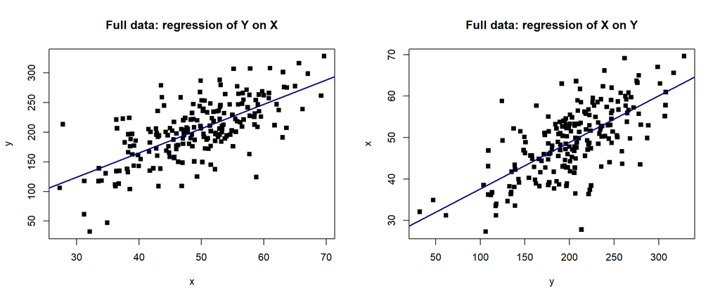

| Parameter | Y on X | X on Y |
| --- | --- | --- |
| $b_0$ | 1.30 | 26.39 |
| $SE(b_0)$ | 15.72 | 1.81 |
| $b_1$ | 4.10 | 0.11 |
| $SE(b_1)$ | 0.31 | 0.01 |

# Complete-case analysis

Aka **listwise deletion**.

Perform the analysis on the observations for which there is no missing value in the variables involved in the analysis.

In MAR data, missingness in X depends on Y.

## Descriptive statistics

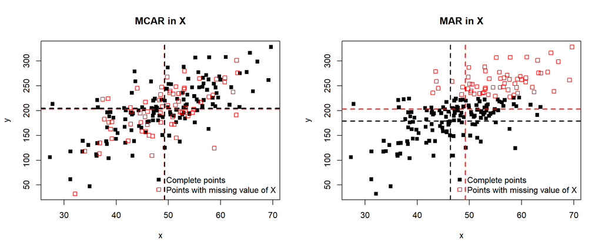

| Statistic | Full | Complete-case (MCAR) | Complete-case (MAR) |
| --- | --- | --- | --- |
| $\overline{X}$ | 49.22 | 49.27 | 46.37 |
| $s_X$ | 8.36 | 8.90 | 7.47 |
| $SE(\overline{X})$ | 0.59 | 0.78 | 0.63 |
| $\overline{Y}$ | 202.95 | 204.38 | 178.62 |
| $s_Y$ | 50.45 | 52.24 | 37.56 |
| $SE(\overline{Y})$ | 3.57 | 4.58 | 3.17 |
| $s_{XY}$ | 286.28 | 328.20 | 151.45 |
| $r_{XY}$ | 0.68 | 0.71 | 0.54 |

## Regression of Y on X

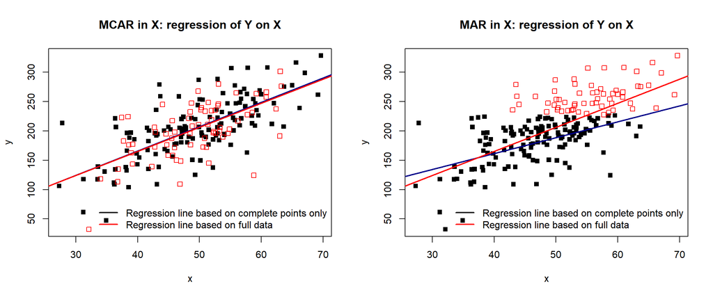

| Parameter | Full | Complete-case (MCAR) | Complete-case (MAR) |
| --- | --- | --- | --- |
| $b_0$ | 1.297 | 0.082 | 52.803 |
| $SE(b_0)$ | 15.719 | 18.395 | 16.920 |
| $b_1$ | 4.097 | 4.147 | 2.714 |
| $SE(b_1)$ | 0.315 | 0.367 | 0.360 |

## Regression of X on Y

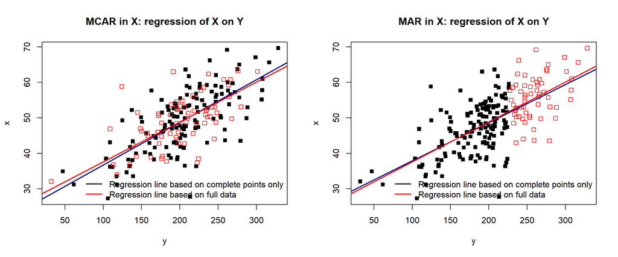

| Parameter | Full | Complete-case (MCAR) | Complete-case (MAR) |
| --- | --- | --- | --- |
| $b_0$ | 26.387 | 24.687 | 27.192 |
| $SE(b_0)$ | 1.808 | 2.248 | 2.601 |
| $b_1$ | 0.112 | 0.120 | 0.107 |
| $SE(b_1)$ | 0.009 | 0.011 | 0.014 |

## Conclusions

### MCAR

- **Unbiased** estimates of **means, variances and regression parameters**.
- **Correct standard errors** and significance levels (but often larger than if the whole sample was available) $\Rightarrow$ **inefficiencies**: lower power, wider CI.

### MAR

- Can yield **biased** estimates of **means, regression parameters and correlations**.
- **In regression: in some specific cases, the best solution!**
  - Regression with **missing values only in the response variable**: listwise deletion and multiple imputation are equivalent. If additional predictors available for multiple imputation: multiple imputation should be preferred over listwise deletion.
  - If **missing values in the dependent and/or the independent variable that do not depend on the dependent variable**: no bias in regression coefficients.

# Mean imputation

Impute the mean for quantitative variables and the mode for categorical ones.

## Descriptive statistics

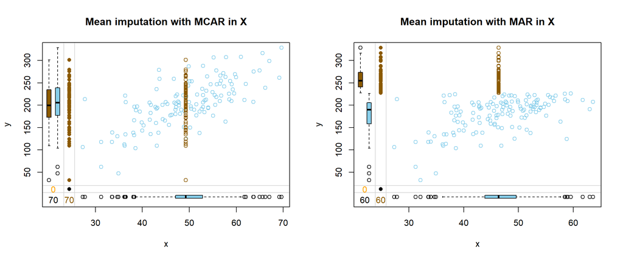

| Statistic | Full | Imputed (MCAR) | Imputed (MAR) |
| --- | --- | --- | --- |
| $\overline{X}$ | 49.22 | 49.27 | 46.37 |
| $s_X$ | 8.36 | 7.16 | 6.24 |
| $SE(\overline{X})$ | 0.59 | 0.51 | 0.44 |
| $\overline{Y}$ | 202.95 | 202.95 | 202.95 |
| $s_Y$ | 50.45 | 50.45 | 50.45 |
| $SE(\overline{Y})$ | 3.57 | 3.57 | 3.57 |
| $s_{XY}$ | 286.28 | 212.75 | 105.78 |
| $r_{XY}$ | 0.68 | 0.59 | 0.34 |

## Regression of Y on X

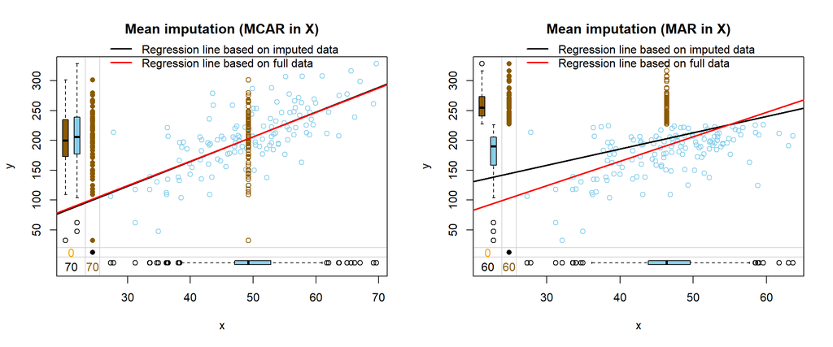

| Parameter | Full | Imputed (MCAR) | Imputed (MAR) |
| --- | --- | --- | --- |
| $b_0$ | 1.30 | -1.35 | 77.13 |
| $SE(b_0)$ | 15.72 | 20.14 | 25.30 |
| $b_1$ | 4.10 | 4.15 | 2.71 |
| $SE(b_1)$ | 0.31 | 0.40 | 0.54 |

## Regression of X on Y

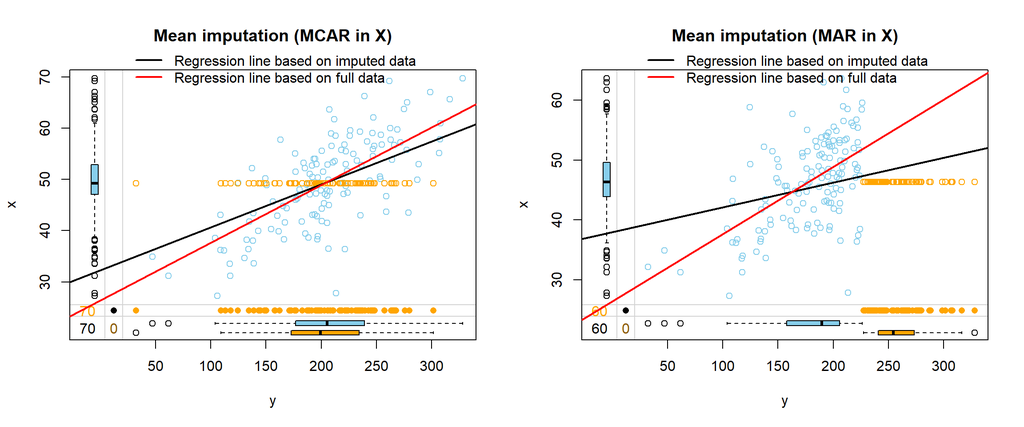

| Parameter | Full | Imputed (MCAR) | Imputed (MAR) |
| --- | --- | --- | --- |
| $b_0$ | 26.39 | 32.30 | 37.93 |
| $SE(b_0)$ | 1.81 | 1.71 | 1.73 |
| $b_1$ | 0.11 | 0.08 | 0.04 |
| $SE(b_1)$ | 0.01 | 0.01 | 0.01 |

## Conclusions

### MCAR

- Downward **bias** in the estimated **variance**.
- **Bias** in almost any estimate other than the mean.
- Disturbs the **relations** between variables.

### MAR

- Downward **bias** in the estimated **variance**.
- **Bias in any estimate.**
- Disturbs the **relations** between variables.

# Regression imputation

Impute predicted value from a linear regression model involving other variables.

## Descriptive statistics

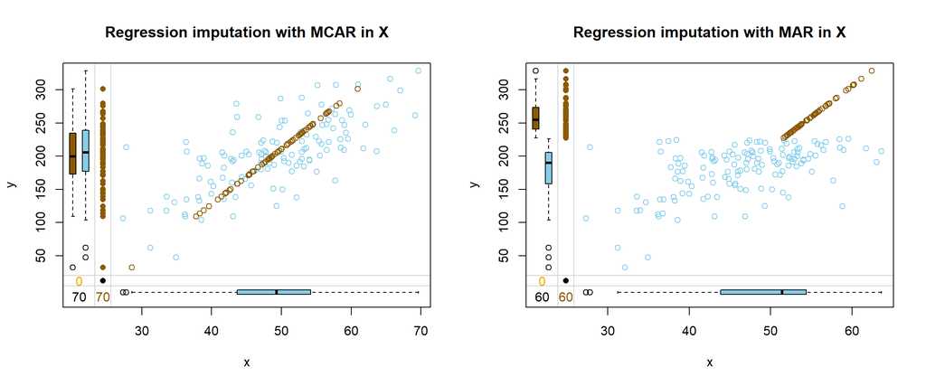

| Statistic | Full | Imputed (MCAR) | Imputed (MAR) |
| --- | --- | --- | --- |
| $\overline{X}$ | 49.22 | 49.09 | 48.98 |
| $s_X$ | 8.36 | 7.91 | 7.55 |
| $SE(\overline{X})$ | 0.59 | 0.56 | 0.53 |
| $\overline{Y}$ | 202.95 | 202.95 | 202.95 |
| $s_Y$ | 50.45 | 50.45 | 50.45 |
| $SE(\overline{Y})$ | 3.57 | 3.57 | 3.57 |
| $s_{XY}$ | 286.28 | 306.06 | 273.17 |
| $r_{XY}$ | 0.68 | 0.77 | 0.72 |

## Regression of Y on X

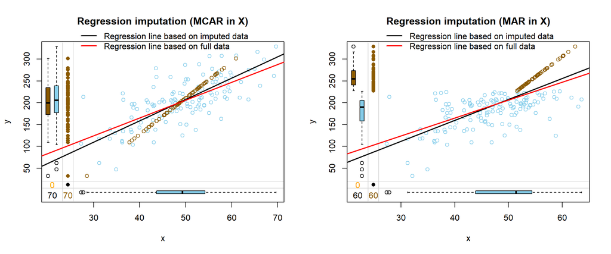

| Parameter | Full | Imputed (MCAR) | Imputed (MAR) |
| --- | --- | --- | --- |
| $b_0$ | 1.297 | -37.358 | -31.979 |
| $SE(b_0)$ | 15.719 | 14.459 | 16.396 |
| $b_1$ | 4.097 | 4.895 | 4.797 |
| $SE(b_1)$ | 0.315 | 0.291 | 0.331 |

## Regression of X on Y

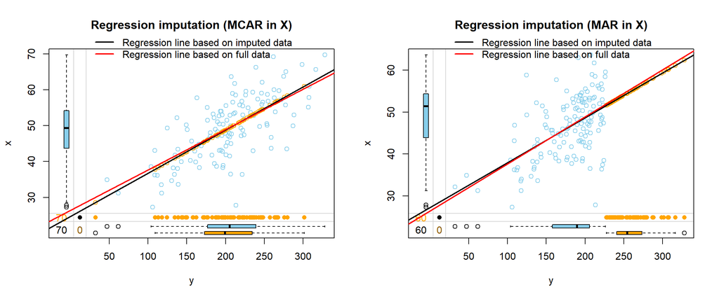

| Parameter | Full | Imputed (MCAR) | Imputed (MAR) |
| --- | --- | --- | --- |
| $b_0$ | 26.387 | 24.687 | 27.192 |
| $SE(b_0)$ | 1.808 | 1.494 | 1.548 |
| $b_1$ | 0.112 | 0.120 | 0.107 |
| $SE(b_1)$ | 0.009 | 0.007 | 0.007 |

## Conclusions

### MCAR

- **Unbiased** estimates of the **means**
- **Unbiased** estimates of the **regression coefficients of the imputation model** if the explanatory variables are complete.
- Downward **bias** in **variance** estimates
- Upward **bias** in **correlation** estimates

### MAR

- **Unbiased** estimates of the **means**
- **Unbiased** estimates of **regression coefficients** if the variables related to missingness are included in the regression model
- Downward **bias** in **variance** estimates
- Upward **bias** in **correlation** estimates**

# Stochastic regression imputation

Same as in regression imputation, but add noise to the predictions.

## Descriptive statistics

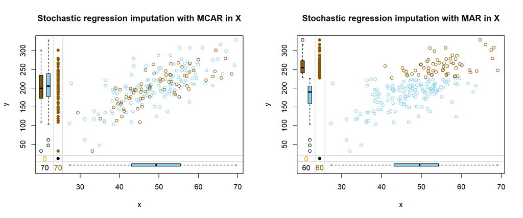

| Statistic | Full | Imputed (MCAR) | Imputed (MAR) |
| --- | --- | --- | --- |
| $\overline{X}$ | 49.22 | 49.31 | 48.98 |
| $s_X$ | 8.36 | 8.72 | 8.17 |
| $SE(\overline{X})$ | 0.59 | 0.62 | 0.58 |
| $\overline{Y}$ | 202.95 | 202.95 | 202.95 |
| $s_Y$ | 50.45 | 50.45 | 50.45 |
| $SE(\overline{Y})$ | 3.57 | 3.57 | 3.57 |
| $s_{XY}$ | 286.28 | 317.37 | 274.33 |
| $r_{XY}$ | 0.68 | 0.72 | 0.67 |

## Regression of Y on X

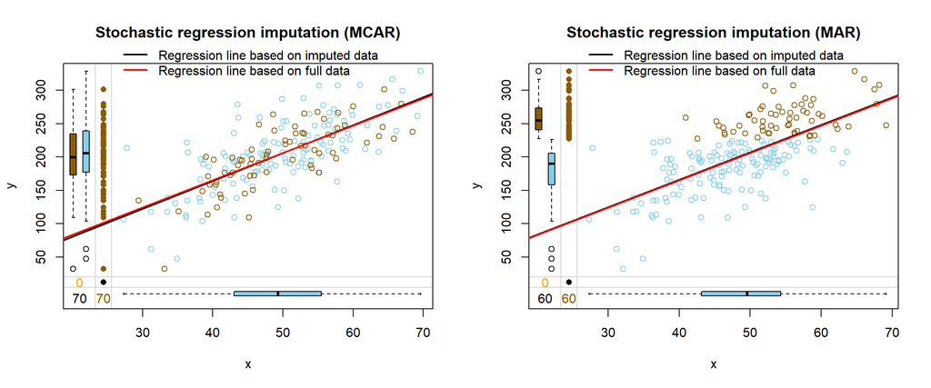

| Parameter | Full | Imputed (MCAR) | Imputed (MAR) |
| --- | --- | --- | --- |
| $b_0$ | 1.297 | -3.031 | 1.700 |
| $SE(b_0)$ | 15.719 | 14.255 | 16.261 |
| $b_1$ | 4.097 | 4.177 | 4.109 |
| $SE(b_1)$ | 0.315 | 0.285 | 0.327 |

## Regression of X on Y

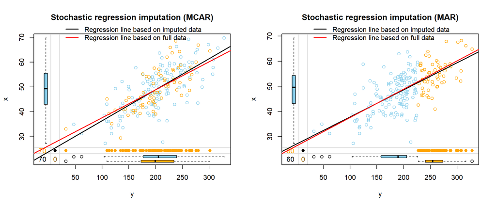

| Parameter | Full | Imputed (MCAR) | Imputed (MAR) |
| --- | --- | --- | --- |
| $b_0$ | 26.387 | 24.002 | 27.106 |
| $SE(b_0)$ | 1.808 | 1.777 | 1.797 |
| $b_1$ | 0.112 | 0.125 | 0.108 |
| $SE(b_1)$ | 0.009 | 0.008 | 0.009 |

## Conclusions

### MCAR

- **Unbiased means**
- **Unbiased regression coefficients** and **correlations**
- Can yield values that are **out of the range of the possible values**.
- Does not take potential **heteroskedasticity** into account.

### MAR

- **Unbiased means**
- **Unbiased regression coefficients** and **correlations**
- Can yield values that are **out of the range of the possible values**.
- Does not take potential **heteroskedasticity** into account.